# Fc-OPG PK/PD in healthy post-menopausal women

# Packages

```r
proj <- "models"
library(mrgsolve)
library(dplyr)
library(magrittr)
library(parallel)
library(ggplot2)
```

## Question

# OPG model

```r
mod <- mread("opg", "model")

mod
```

```
.
.
. -------- mrgsolve model object (unix) --------
.   Project: /Users/kyleb/git/metrumresearchgroup/lvl2-workshop/model
.   source:        opg.cpp
.   shared object: opg-so-1019e68db3edc
.
.   compile date:
.   Time:          start: 0 end: 24 delta: 1
.   >              add: <none>
.   >              tscale: 1
.
.   Compartments:  SC CENT P1 P2 NTX [5]
.   Parameters:    IV TVCL TVVC TVVP1 TVVP2 TVQ1
.   >              TVQ2 TVKA TVVMAX TVKM TVFSC TVKSYN
.   >              TVKDEG TVIC50 [14]
.   Omega:         10x10
.   Sigma:         4x4
.
.   Solver:        atol: 1e-08 rtol: 1e-08
.   >              maxsteps: 2000 hmin: 0 hmax: 0
```

Checkout the random effects structure

```r
revar(mod)
```

```
. $omega
. $...
.           [,1]   [,2]   [,3]   [,4]   [,5]   [,6]  [,7]  [,8]   [,9] [,10]
. ECL:    0.0391 0.0000 0.0000 0.0000 0.0000 0.0000 0.000 0.000 0.0000  0.00
. EVC:    0.0000 0.0102 0.0000 0.0000 0.0000 0.0000 0.000 0.000 0.0000  0.00
. EVP1:   0.0000 0.0000 0.0144 0.0000 0.0000 0.0000 0.000 0.000 0.0000  0.00
. EVP2:   0.0000 0.0000 0.0000 0.0333 0.0000 0.0000 0.000 0.000 0.0000  0.00
. EQ1:    0.0000 0.0000 0.0000 0.0000 0.0379 0.0000 0.000 0.000 0.0000  0.00
. EKA:    0.0000 0.0000 0.0000 0.0000 0.0000 0.0457 0.000 0.000 0.0000  0.00
. EFSC:   0.0000 0.0000 0.0000 0.0000 0.0000 0.0000 0.263 0.000 0.0000  0.00
. EKSYN:  0.0000 0.0000 0.0000 0.0000 0.0000 0.0000 0.000 0.281 0.0000  0.00
. EKDEG:  0.0000 0.0000 0.0000 0.0000 0.0000 0.0000 0.000 0.000 0.0325  0.00
. EIC50:  0.0000 0.0000 0.0000 0.0000 0.0000 0.0000 0.000 0.000 0.0000  1.18
.
.
. $sigma
. $...
.            [,1]  [,2]   [,3] [,4]
. ADDIV:   0.0193 0.000 0.0000  0.0
. ADDSC:   0.0000 0.733 0.0000  0.0
. PDPROP:  0.0000 0.000 0.0407  0.0
. PDADD:   0.0000 0.000 0.0000 20.7
```

```r
mod %<>% mrgsolve:::collapse_omega()
mod %<>% mrgsolve:::collapse_sigma()
```

We can render this in to an `Rmarkdown` document

```r
mrgsolve:::render(mod)
```

# Load the simulated posterior

```r
post <- readRDS("data/opgpost.RDS") %>% sample_n(1000)
```

For most of our examples, we are taking output directly from a NONMEM run. This example is a little different: We have changed the column names from `THETA1`, `THETA2` etc … to `TVCL`, `TVVC` etc …

```r
head(post)
```

[output not shown]

When working with results out of NONMEM, it is common to get the `THETA` , `OMEGA` and `SIGMA` estimates all in a single row in a data frame.

In order to get the information for `OMEGA` and `SIGMA` in to the problem, we need to go into this data and form matrices.

There are two specialized functions to help with this:

- `as_bmat` when the data is in block format
- `as_dmat` when the data is in diagonal format

```r
omegas <- as_bmat(post,"OMEGA")
sigmas <- as_bmat(post,"SIGMA")
```

Here is a simple dosing data set to simulate 100 patients with 3 mg/kg Fc-OPG SC x1

```r
sc3 <- expand.ev(ID=1:100, amt=210, cmt=1)
head(sc3)
```

```
.   ID amt cmt evid time
. 1  1 210   1    1    0
. 2  2 210   1    1    0
. 3  3 210   1    1    0
. 4  4 210   1    1    0
. 5  5 210   1    1    0
. 6  6 210   1    1    0
```

We will get the observation design for the simulation through a `tgrid` object

```r
des <- tgrid(end=-1,add=c(0,24*14))
des
```

```
. start:  0  end:    -1  delta:  1  offset: 0  min:    0   max:    336
```

When we do replicate simulation, it almost always pays off to construct a function that will carry out one replicate.

Arguments to the function are

- `i` the current simulation replicate
- `data` the dosing data set
- `des` the observation design

```r
sim <- function(i,data,des) {

  mod %<>%
    param(slice(post,i)) %>%
    omat(omegas[[i]]) %>%
    smat(sigmas[[i]])

  mod %>%
    Req(PDDV) %>%
    mrgsim(data=data,tgrid=des,obsonly=TRUE) %>%
    mutate(irep=i) %>%
    mutate(TVIC50=mod$TVIC50, TVQ1=mod$TVQ1, TVVMAX=mod$TVVMAX)
}
```

It is easy to test the function. The 10th replicate will look like this

```r
sim(10,sc3,des)
```

```
. # A tibble: 200 x 7
.       ID  time     PDDV  irep TVIC50  TVQ1 TVVMAX
.    <dbl> <dbl>    <dbl> <dbl>  <dbl> <dbl>  <dbl>
.  1     1     0 73.24125    10  4.849 18.04  10930
.  2     1   336 84.45242    10  4.849 18.04  10930
.  3     2     0 40.86646    10  4.849 18.04  10930
.  4     2   336 14.80692    10  4.849 18.04  10930
.  5     3     0 31.80177    10  4.849 18.04  10930
.  6     3   336 26.94407    10  4.849 18.04  10930
.  7     4     0 15.95565    10  4.849 18.04  10930
.  8     4   336 13.16099    10  4.849 18.04  10930
.  9     5     0 26.56274    10  4.849 18.04  10930
. 10     5   336 21.47061    10  4.849 18.04  10930
. # ... with 190 more rows
```

Simulate reps

```r
options(mc.cores=8)
mcRNG()
set.seed(22223)
out <- mclapply(1:1000, sim, data=sc3,des=des) %>% bind_rows
```

Summarise

- First, get the baseline `NTX`
- Then calculate percent CFB

```r
sum <-
  out %>%
  group_by(ID,irep) %>%
  mutate(BASE = first(PDDV), dDV = 100*(PDDV-BASE)/BASE) %>%
  ungroup
```

Filter down to week 2

```r
sum %<>% filter(time==336 & BASE >= 0)
```

Now, get the median

```r
summ <-
  sum %>%
  filter(time==336) %>%
  group_by(irep) %>%
  summarise(med = median(dDV))
```

## From the abstract

> Subsequent clinical trial simulations demonstrated that a single 3.0-mg/kg SC dose of Fc-OPG would be expected to produce, at 14 days post-dose, a median NTX percentage change from baseline of −45% (with a 95% prediction interval ranging from −34% to −60%)."

```r
ans <- signif(quantile(summ$med, c(0.5,0.025,0.975)),3)

paste0(ans[1], " (", ans[3],",",ans[2],")")
```

```
. [1] "-45.9 (-32,-61.9)"
```

Median week-2 change from baseline with 95% interval

Probability that median cfb > 40%

```r
mean(summ$med < -40)
```

```
. [1] 0.808
```

Plot the distribution of the week-2 change from baseline

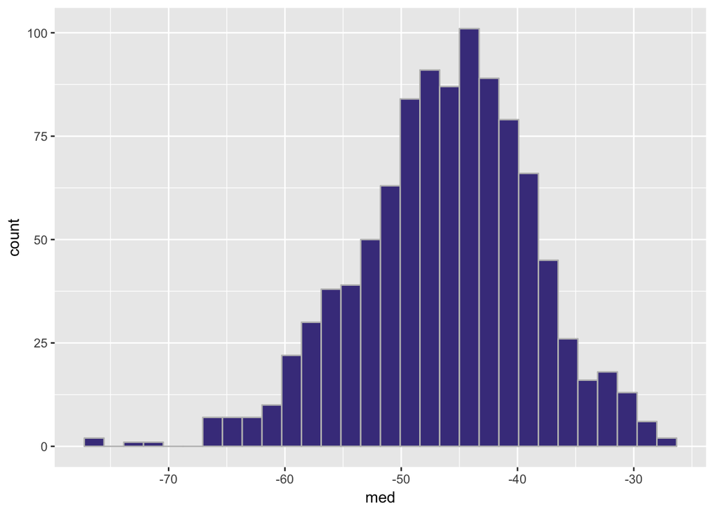

```r
ggplot(summ, aes(x=med)) +
  geom_histogram(fill="darkslateblue", col="grey")
```

# Sensitivity analysis

We are already set up to do the sensitivity analysis

```r
par <- dplyr::distinct(out,irep,TVIC50,TVQ1,TVVMAX)
head(par)
```

```
. # A tibble: 6 x 4
.    irep TVIC50  TVQ1 TVVMAX
.   <int>  <dbl> <dbl>  <dbl>
. 1     1  6.213 14.99  12170
. 2     2  6.558 16.53  13870
. 3     3  5.432 15.83   8100
. 4     4  4.592 13.41  14380
. 5     5  5.958 11.92  13540
. 6     6  5.744 17.69  13970
```

```r
sens <- left_join(summ,par)
head(sens)
```

```
. # A tibble: 6 x 5
.    irep       med TVIC50  TVQ1 TVVMAX
.   <int>     <dbl>  <dbl> <dbl>  <dbl>
. 1     1 -42.06966  6.213 14.99  12170
. 2     2 -44.10213  6.558 16.53  13870
. 3     3 -71.42010  5.432 15.83   8100
. 4     4 -32.01692  4.592 13.41  14380
. 5     5 -47.68609  5.958 11.92  13540
. 6     6 -45.31841  5.744 17.69  13970
```

`TVIC50`

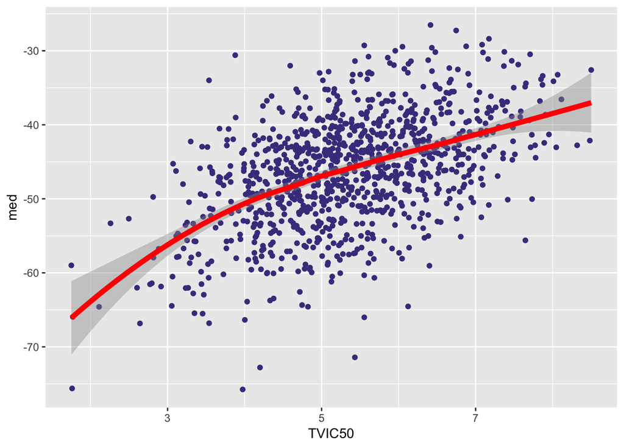

```r
ggplot(sens, aes(TVIC50, med)) +
  geom_point(col="darkslateblue") +
  geom_smooth(method="loess",col="red",lwd=2)
```

`TVVMAX`

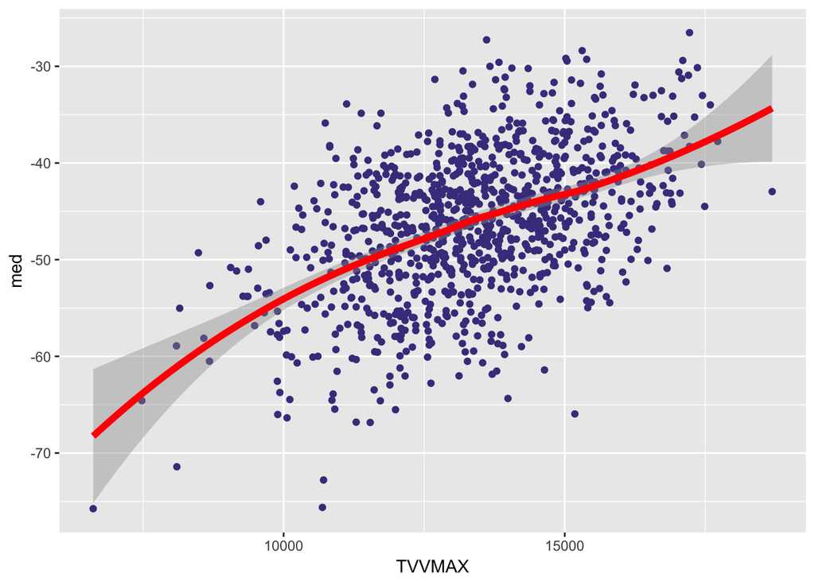

```r
ggplot(sens, aes(TVVMAX, med)) +
  geom_point(col="darkslateblue") +
  geom_smooth(method="loess",col="red",lwd=2)
```

`TVQ`

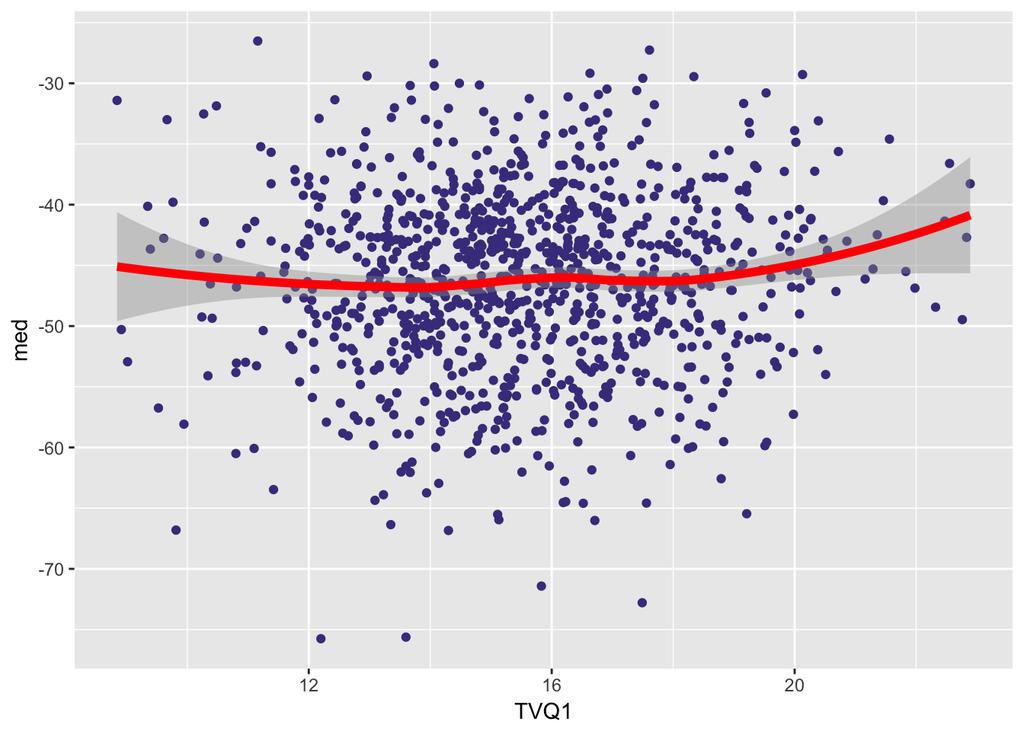

```r
ggplot(sens, aes(TVQ1, med)) +
  geom_point(col="darkslateblue") +
  geom_smooth(method="loess",col="red",lwd=2)
```